# R Notebook

```r
##install.packages("tidyverse")
library(tidyverse)
library(cluster)    # clustering algorithms
##install.packages("factoextra")
library(factoextra) # clustering visualization
##install.packages("ggplot2")
library(dendextend) # for comparing two dendrograms
##install.packages("sparcl")
library(sparcl)     #to create colourDendograms
```

```r
Csdata<- read.csv("Cereals.csv")
```

```r
Csdata1<- na.omit(Csdata) ##remove the missing value
```

```r
Csdata2<-Csdata1[,c(-2,-3)] ## excluding catagorical variable
head(Csdata2)
```

|  | name | calories | protein | fat | sodium | fiber | carbo | sugars | potass | vitamins | shelf | weight | cups | rating |
| --- | --- | --- | --- | --- | --- | --- | --- | --- | --- | --- | --- | --- | --- | --- |
| 1 | 100%_Bran | 70 | 4 | 1 | 130 | 10.0 | 5.0 | 6 | 280 | 25 | 3 | 1 | 0.33 | 68.40297 |
| 2 | 100%_Natural_Bran | 120 | 3 | 5 | 15 | 2.0 | 8.0 | 8 | 135 | 0 | 3 | 1 | 1.00 | 33.98368 |
| 3 | All-Bran | 70 | 4 | 1 | 260 | 9.0 | 7.0 | 5 | 320 | 25 | 3 | 1 | 0.33 | 59.42551 |
| 4 | All-Bran_with_Extra_Fiber | 50 | 4 | 0 | 140 | 14.0 | 8.0 | 0 | 330 | 25 | 3 | 1 | 0.50 | 93.70491 |
| 6 | Apple_Cinnamon_Cheerios | 110 | 2 | 2 | 180 | 1.5 | 10.5 | 10 | 70 | 25 | 1 | 1 | 0.75 | 29.50954 |
| 7 | Apple_Jacks | 110 | 2 | 0 | 125 | 1.0 | 11.0 | 14 | 30 | 25 | 2 | 1 | 1.00 | 33.17409 |

```r
str(Csdata2)
```

```
'data.frame':   74 obs. of  14 variables:
 $ name    : Factor w/ 77 levels "100%_Bran","100%_Natural_Bran",..: 1 2 3 4 6 7 8 9 10 11 ...
 $ calories: int  70 120 70 50 110 110 130 90 90 120 ...
 $ protein : int  4 3 4 4 2 2 3 2 3 1 ...
 $ fat     : int  1 5 1 0 2 0 2 1 0 2 ...
 $ sodium  : int  130 15 260 140 180 125 210 200 210 220 ...
 $ fiber   : num  10 2 9 14 1.5 1 2 4 5 0 ...
 $ carbo   : num  5 8 7 8 10.5 11 18 15 13 12 ...
 $ sugars  : int  6 8 5 0 10 14 8 6 5 12 ...
 $ potass  : int  280 135 320 330 70 30 100 125 190 35 ...
 $ vitamins: int  25 0 25 25 25 25 25 25 25 25 ...
 $ shelf   : int  3 3 3 3 1 2 3 1 3 2 ...
 $ weight  : num  1 1 1 1 1 1 1.33 1 1 1 ...
 $ cups    : num  0.33 1 0.33 0.5 0.75 1 0.75 0.67 0.67 0.75 ...
 $ rating  : num  68.4 34 59.4 93.7 29.5 ...
```

```r
summary(Csdata2)
```

```
                        name       calories      protein           fat        sodium          fiber
 100%_Bran                : 1   Min.   : 50   Min.   :1.000   Min.   :0   Min.   :  0.0   Min.   : 0.000
 100%_Natural_Bran        : 1   1st Qu.:100   1st Qu.:2.000   1st Qu.:0   1st Qu.:135.0   1st Qu.: 0.250
 All-Bran                 : 1   Median :110   Median :2.500   Median :1   Median :180.0   Median : 2.000
 All-Bran_with_Extra_Fiber: 1   Mean   :107   Mean   :2.514   Mean   :1   Mean   :162.4   Mean   : 2.176
 Apple_Cinnamon_Cheerios  : 1   3rd Qu.:110   3rd Qu.:3.000   3rd Qu.:1   3rd Qu.:217.5   3rd Qu.: 3.000
 Apple_Jacks              : 1   Max.   :160   Max.   :6.000   Max.   :5   Max.   :320.0   Max.   :14.000
 (Other)                  :68
     carbo           sugars           potass          vitamins          shelf           weight
 Min.   : 5.00   Min.   : 0.000   Min.   : 15.00   Min.   :  0.00   Min.   :1.000   Min.   :0.500
 1st Qu.:12.00   1st Qu.: 3.000   1st Qu.: 41.25   1st Qu.: 25.00   1st Qu.:1.250   1st Qu.:1.000
 Median :14.50   Median : 7.000   Median : 90.00   Median : 25.00   Median :2.000   Median :1.000
 Mean   :14.73   Mean   : 7.108   Mean   : 98.51   Mean   : 29.05   Mean   :2.216   Mean   :1.031
 3rd Qu.:17.00   3rd Qu.:11.000   3rd Qu.:120.00   3rd Qu.: 25.00   3rd Qu.:3.000   3rd Qu.:1.000
 Max.   :23.00   Max.   :15.000   Max.   :330.00   Max.   :100.00   Max.   :3.000   Max.   :1.500

      cups            rating
 Min.   :0.2500   Min.   :18.04
 1st Qu.:0.6700   1st Qu.:32.45
 Median :0.7500   Median :40.25
 Mean   :0.8216   Mean   :42.37
 3rd Qu.:1.0000   3rd Qu.:50.52
 Max.   :1.5000   Max.   :93.70
```

```r
rownames(Csdata2) <- Csdata2$name ##Convert the names of the breakfast cereals to the row names, as this will later help us in visualising the clusters
```

```r
Csdata2 <- Csdata2[,c(-1)] ##Drop the name column as it is now just redundant information
```

```r
##The data must be scaled, before measuring any type of distance metric as the variables with higher ranges will significantly influence the distance
Csdata2 <- scale(Csdata2)
head(Csdata2)
```

```
                            calories    protein        fat     sodium       fiber      carbo     sugars
100%_Bran                 -1.8659155  1.3817478  0.0000000 -0.3910227  3.22866747 -2.5001396 -0.2542051
100%_Natural_Bran          0.6537514  0.4522084  3.9728810 -1.7804186 -0.07249167 -1.7292632  0.2046041
All-Bran                  -1.8659155  1.3817478  0.0000000  1.1795987  2.81602258 -1.9862220 -0.4836096
All-Bran_with_Extra_Fiber -2.8737823  1.3817478 -0.9932203 -0.2702057  4.87924705 -1.7292632 -1.6306324
Apple_Cinnamon_Cheerios    0.1498180 -0.4773310  0.9932203  0.2130625 -0.27881412 -1.0868662  0.6634132
Apple_Jacks                0.1498180 -0.4773310 -0.9932203 -0.4514312 -0.48513656 -0.9583868  1.5810314
                              potass   vitamins      shelf     weight       cups     rating
100%_Bran                  2.5605229 -0.1818422  0.9419715 -0.2008324 -2.0856582  1.8549038
100%_Natural_Bran          0.5147738 -1.3032024  0.9419715 -0.2008324  0.7567534 -0.5977113
All-Bran                   3.1248675 -0.1818422  0.9419715 -0.2008324 -2.0856582  1.2151965
All-Bran_with_Extra_Fiber  3.2659536 -0.1818422  0.9419715 -0.2008324 -1.3644493  3.6578436
Apple_Cinnamon_Cheerios   -0.4022862 -0.1818422 -1.4616799 -0.2008324 -0.3038480 -0.9165248
Apple_Jacks               -0.9666308 -0.1818422 -0.2598542 -0.2008324  0.7567534 -0.6553998
```

Qs1 Apply hierarchical clustering to the data using Euclidean distance to the normalized measurements. Use Agnes to compare the clustering from single linkage, complete linkage, average linkage and Ward. Choose the best method.

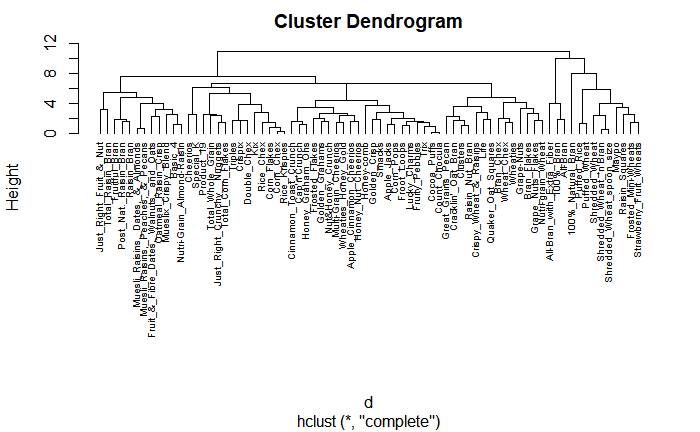

```r
# Dissimilarity matrix
d <- dist(Csdata2, method = "euclidean")

# Hierarchical clustering using Complete Linkage
hc_complete <- hclust(d, method = "complete" )

# Plot the obtained dendrogram
plot(hc_complete, cex = 0.6, hang = -1)
```

Using Agnes to compare the clustering from single linkage, complete linkage, average linkage, and Ward and comparing agglomerative coefficients of each method.

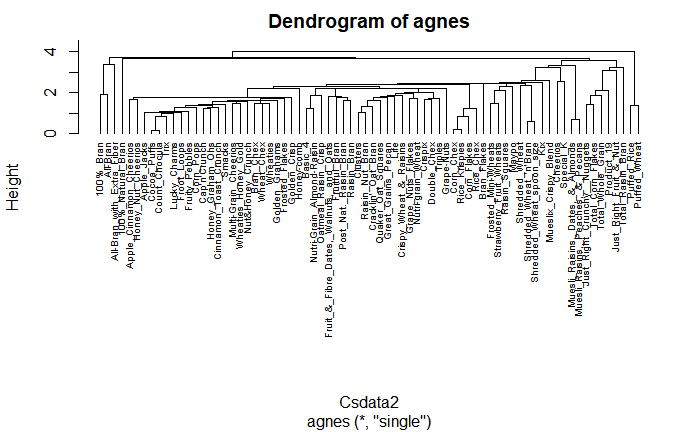

```r
hc_single <- agnes(Csdata2, method = "single")
pltree(hc_single, cex = 0.6, hang = -1, main = "Dendrogram of agnes")
```

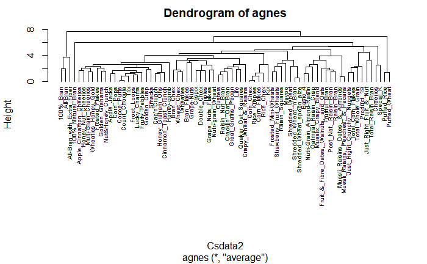

```r
hc_average <- agnes(Csdata2, method = "average")
pltree(hc_average, cex = 0.6, hang = -1, main = "Dendrogram of agnes")
```

```r
# Compute with agnes
hc_complete <- agnes(Csdata2, method = "complete")

# Agglomerative coefficient
hc_complete$ac
```

```
[1] 0.8353712
```

```r
##We will find the agnes coefficient of all the methods.

library(tidyverse)
# methods to assess

m <- c( "average", "single", "complete", "ward")
names(m) <- c( "average", "single", "complete", "ward")

# function to compute coefficient
ac <- function(x) {
  agnes(Csdata2, method = x)$ac
}

map_dbl(m, ac)
```

```
  average    single  complete      ward
0.7766075 0.6067859 0.8353712 0.9046042
```

The best linkage method is ward with agglomerative coefficient of 0.9046042.

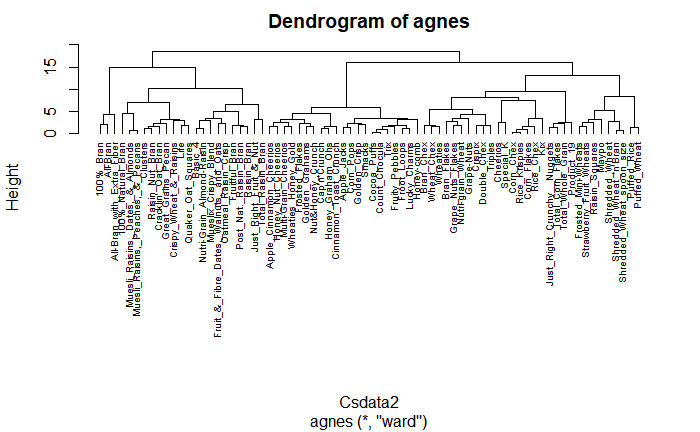

```r
hc_ward <- agnes(Csdata2, method = "ward")
pltree(hc_ward, cex = 0.6, hang = -1, main = "Dendrogram of agnes") ##visualizing the dendrogram using wards method:
```

Qs 2) How many clusters would you choose?

Referring the dendrogram, a suitable height shall be chosen where a horizontal line shall be plotted and the number of instances where the horizontal line cut the branches of dendrogram are clusters of our data. So, our hierarchical clustering analysis is producing 6 clusters.

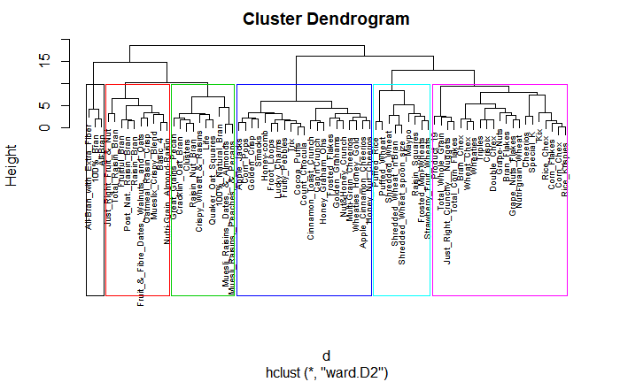

```r
#Create the distance matrix
d <- dist(Csdata2, method = "euclidean")

# Ward's method for Hierarchical clustering
hc_ward_cut <- hclust(d, method = "ward.D2" )

plot(hc_ward_cut, cex=0.6 )
rect.hclust(hc_ward_cut,k=6,border = 1:6)
```

```r
##Lets see how many number of records of the data grouped and assigned  to clusters
# Cut tree into 6 groups
sub_grp <- cutree(hc_ward_cut, k = 6)

# Number of members in each cluster
table(sub_grp)
```

```
sub_grp
 1  2  3  4  5  6
 3 10 21 10 21  9
```

```r
cluster <- cutree(hc_ward,k=6)
cluster
```

```
                             100%_Bran                      100%_Natural_Bran
                                     1                                      2
                              All-Bran              All-Bran_with_Extra_Fiber
                                     1                                      1
               Apple_Cinnamon_Cheerios                            Apple_Jacks
                                     3                                      3
                               Basic_4                              Bran_Chex
                                     4                                      5
                           Bran_Flakes                           Cap'n'Crunch
                                     5                                      3
                              Cheerios                  Cinnamon_Toast_Crunch
                                     5                                      3
                              Clusters                            Cocoa_Puffs
                                     2                                      3
                             Corn_Chex                            Corn_Flakes
                                     5                                      5
                             Corn_Pops                          Count_Chocula
                                     3                                      3
                    Cracklin'_Oat_Bran                                Crispix
                                     2                                      5
                Crispy_Wheat_&_Raisins                            Double_Chex
                                     2                                      5
                           Froot_Loops                         Frosted_Flakes
                                     3                                      3
                   Frosted_Mini-Wheats Fruit_&_Fibre_Dates,_Walnuts,_and_Oats
                                     6                                      4
                         Fruitful_Bran                         Fruity_Pebbles
                                     4                                      3
                          Golden_Crisp                         Golden_Grahams
                                     3                                      3
                     Grape_Nuts_Flakes                             Grape-Nuts
                                     5                                      5
                    Great_Grains_Pecan                       Honey_Graham_Ohs
                                     2                                      3
                    Honey_Nut_Cheerios                             Honey-comb
                                     3                                      3
           Just_Right_Crunchy__Nuggets                 Just_Right_Fruit_&_Nut
                                     5                                      4
                                   Kix                                   Life
                                     5                                      2
```

[output cut: 19 more lines]

```
                                     5                                      5
                        Shredded_Wheat                 Shredded_Wheat_'n'Bran
                                     6                                      6
             Shredded_Wheat_spoon_size                                 Smacks
                                     6                                      3
                             Special_K                Strawberry_Fruit_Wheats
                                     5                                      6
                     Total_Corn_Flakes                      Total_Raisin_Bran
                                     5                                      4
                     Total_Whole_Grain                                Triples
                                     5                                      5
                                  Trix                             Wheat_Chex
                                     3                                      5
                              Wheaties                    Wheaties_Honey_Gold
                                     5                                      3
```

QS3) Comment on the structure of the clusters and on their stability. Hint: To check stability, partition the data and see how well clusters formed based on one part apply to the other part. To do this: Cluster partition A Use the cluster centroids from A to assign each record in partition B (each record is assigned to the cluster with the closest centroid). Assess how consistent the cluster assignments are compared to the assignments based on all the data.

```r
library(knitr)
library(dendextend)
library(ggplot2)
##install.packages("hrbrthemes")
library(hrbrthemes)
##install.packages("viridisLite")
library(viridis)
ce <-data.frame(cbind(Csdata2,cluster))  ## combining cluster lable with subset of the data to view all information in one table




csdata3 <- na.omit(Csdata) ##creating new subset of data and deleting rows with "NA" value

train.data <- csdata3[1:60,]  ## creating partition of subset  by taking first 60 row
test.data <- csdata3[61:74,]  ## creating partition of subset  by taking next 14 row of"newdata"

train <- scale(train.data[,-c(1:3)]) ## Standardizing data for all numeric data for subset
test <- scale(test.data[,-c(1:3)]) ## Standardizing data for all numeric data for subset

# Computing  agnes with different linkage method to identify highest coefficients



train_ward<- agnes(train,method = "ward")
train_avg<-agnes(train,method="average")
train_com<-agnes(train,method="complete")
train_sin<-agnes(train,method="single")
kable(cbind(ward=train_ward$ac,average=train_avg$ac,complete=train_com$ac,single=train_sin$ac)) ## this function provide information for Agglomerative coefficients for all linkage in a tabular format and easily view
```

| ward | average | complete | single |
| --- | --- | --- | --- |
| 0.8898441 | 0.7567786 | 0.8207517 | 0.6672134 |